# Data Science Capstone - Milestone Report

Yanal Kashou

November 27, 2016

### Project Overview

This is the milestone report for the **Coursera Data Science Capstone Project** in which we aim to implement an algorithm to predict the next word, given raw text data that needs to be cleaned and analysed.

The course was developed by **Johns Hopkins University** in collaboration with **Swiftkey**.

The topic of our report is **NLP (Natural Language Processing)**.

### Our Data

#### Obtaining the Data

We obtained the data from the following URL:

https://d396qusza40orc.cloudfront.net/dsscapstone/dataset/Coursera-SwiftKey.zip

It is in the form of a 548mb compressed `.zip` folder that contains multiple datasets in various locales or languages; from which we extracted the desired datasets.

#### Data Loading

We are required to load three large text files into the `R Workspace`, explore these files and clean them, before we begin with the processing of their content.

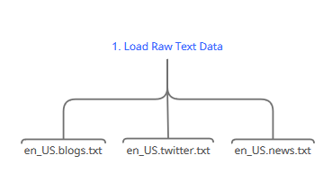

| Dataset | Size (MB) | Line Count | Word Count | Character Count |
| --- | --- | --- | --- | --- |
| Blogs | 210.1600 | 899288 | 37334441 | 208361438 |
| News | 205.8119 | 77259 | 2643972 | 15683765 |
| Twitter | 167.1053 | 2360148 | 30373792 | 162384825 |

#### Data Sampling and Cleaning

To make it easier for computation, we have to reduce the size of the data to an acceptable value, in this case we took a random binomial sample of 15% of each dataset to work with, clean, analyze and visualize.

Outlined below are the pre-processing steps we walked through:

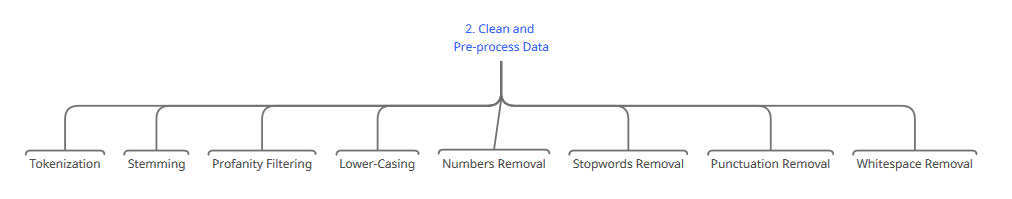

| Dataset | Sample Size (MB) | Line Count | Word Count | Character Count |
| --- | --- | --- | --- | --- |
| Blogs | 31.478460 | 134893 | 6746353 | 31208674 |
| News | 2.260465 | 11588 | 458161 | 2237289 |
| Twitter | 24.998476 | 354022 | 5550447 | 24290432 |

We used the `tm` package to perform these steps and we left the stemming procedure to be performed automatically as we created a **Document Feature Matrix** using the `quanteda` package for each document in the corpus. This was done because stemming using the `tm` package caused word content to be ruined and require a further process called `stemCompletion`.

| Dataset | Post-Sampling Word Count | Post-Cleaning Word Count | % Decrease |
| --- | --- | --- | --- |
| Blogs | 6746353 | 3220738 | 52.25957 |
| News | 458161 | 229876 | 49.82637 |
| Twitter | 5550447 | 2843403 | 48.77164 |

### N-Grams

We used `NGramTokenizer` from the `RWeka` package to find the most frequent **unigrams**, **bigrams**, **trigrams** and **fourgrams**; also to produce the values below:

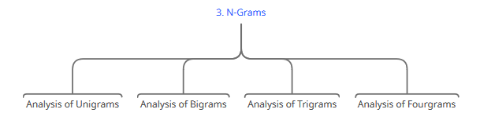

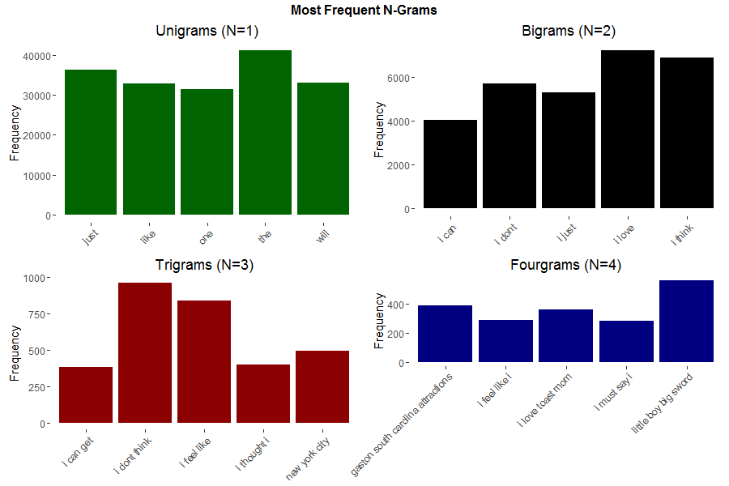

### Further Plans

#### Considerations

- The N-Grams frequency model produced is of our random sample of 15% of the dataset. If we performed another random sample, the most frequent words might change.
- If there is a way to create an N-Gram model of the entire dataset without sampling and without affecting app performance, this would be our best solution for high accuracy. Cannot be confirmed until further testing.
- We can use a classification algorithm to detect the N-Grams, and then predict accordingly.
- Further research on probabilistic models is important before a decision is made on which algorithm to implement.

#### Algorithm

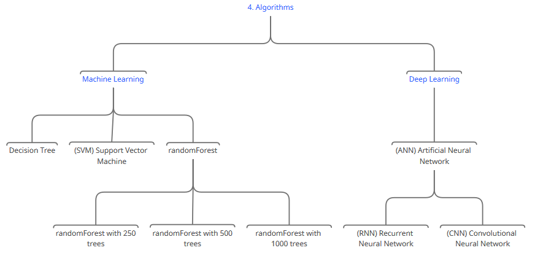

**Machine Learning**

- Decision Tree logically must be the fastest algorithm to use if we are to grab the most frequent words of (N + 1) Grams. That essentially means that if a person enters a single word (N = 1), then the most probable next word is a Bigram (1 + 1). Subsequently if a person enters 2 words or 3 words, then we know the next word must come from Trigrams or Fourgrams respectively.
- SVMs are very efficient, accurate but slower than decision trees when implemented.
- randomForest is a great choice for accuracy, but we must select an optimal number of trees to balance accuracy and computational efficiency.

**Deep Learning**

- (ANNs) Artificial Neural Networks present a very different and difficult challange where we must come up with a mathematical model for the algorithm to be implemented. Two great solutions to NLP are (CNNs) Convolutional Neural Netwoks and (RNNs) Recurrent Neural Networks.
- ANNs are usually *very* computationally intensive and will restrict us to use a very small sample from the dataset.
- We might attempt at the implementation of an ANN, however this will be left for later after the machine learning algorithms in the above section have been tested, timed and implemented.

#### Data Product

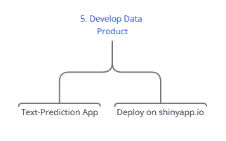

The concept is simple enough:

- A text field that takes a string input, and observes an event where (space) is entered after a word.
- The observed event triggers the prediction algorithm, cancels immediately if the person continues typing.
- The algorithm results and/or confidence levels are displayed reactively.
- A bit of UI work can be beneficial for both the user and the developer. An attractive app is an app that more people will use.
- Deploy the application on [shinyapps.io](http://www.shinyapps.io/).

### Source Code

For access to my GitHub Repository associated with this project, please visit the URL below:  
[Data Science Capstone](https://github.com/ykashou92/DataScienceCapstone)